# An Introduction of DSLs, Distplyr and Distionary

```r
#eval_survival(dst_invert, at = 2)
```

- `maximise`.

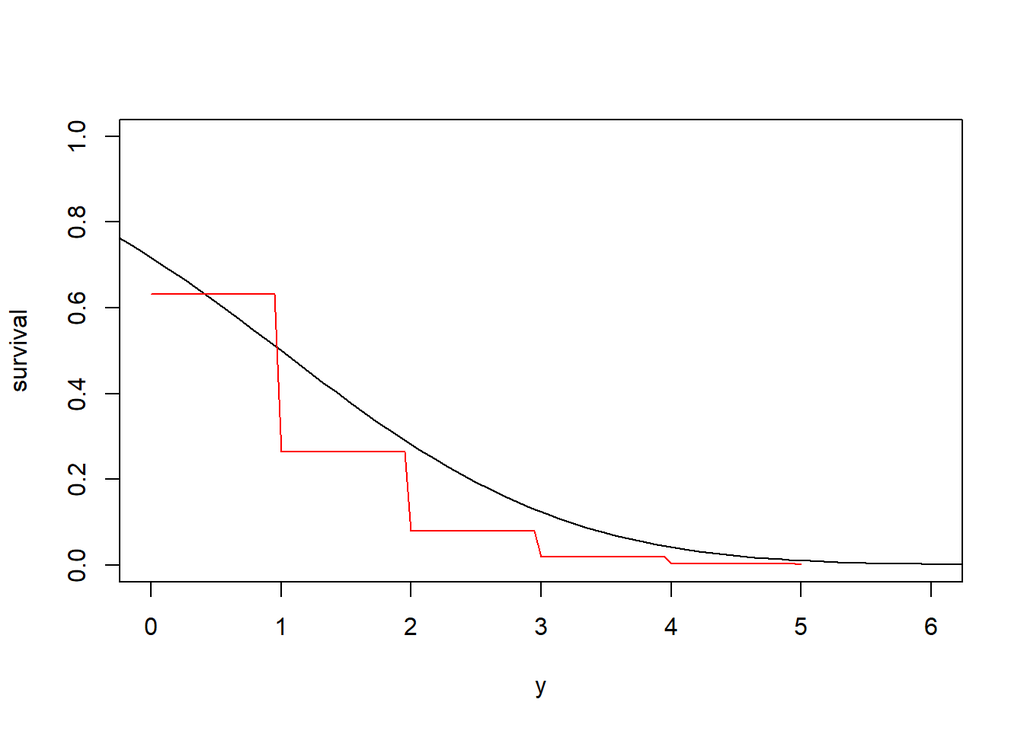

```r
plot(dst_1, "survival", xlim = c(0, 6))

plot(dst_3, "survival", add = TRUE, col = "red")
```

```r
(dst_max = maximise(dst_1, dst_3))
```

```
## max dst
##
##  components :
## $distributions
## $distributions[[1]]
## norm parametric dst
##
##  name :
## [1] "norm"
##
## $distributions[[2]]
## pois parametric dst
##
##  name :
## [1] "pois"
##
##
## $draws
## [1] 1 1
```

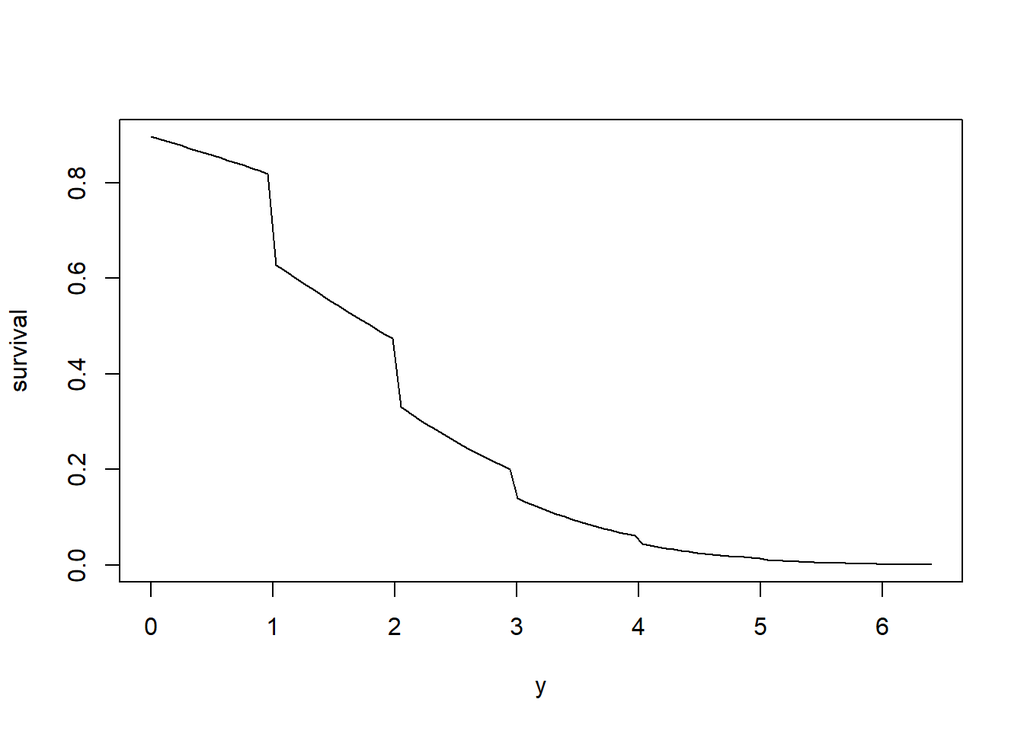

```r
plot(dst_max, "survival")
```

- `slice` function removes probability to the left or the right of some breakpoint, conditioning the random variable to be the leftover part. There is an option to include the breakpoint probability in case the probability is non-zero.

```r
(dst_slice_l <- slice_left(dst_3, breakpoint = 2))
```

```
## slice_left dst
##
##  distribution :
## pois parametric dst
##
##  name :
## [1] "pois"
```

```r
(dst_slice_r <- slice_right(dst_1, breakpoint = 2))
```

```
## slice_right dst
##
##  distribution :
## norm parametric dst
##
##  name :
## [1] "norm"
```

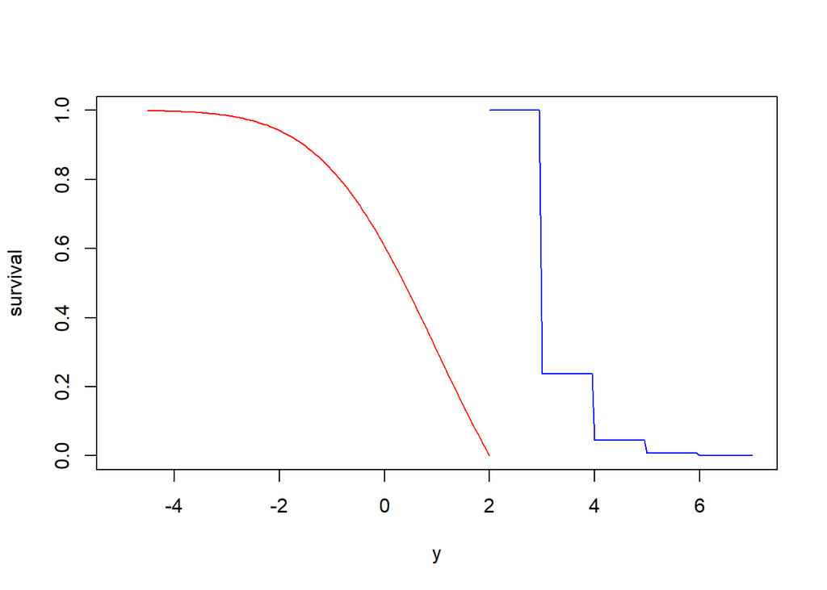

```r
plot(dst_slice_l, "survival", xlim=c(-5, 7), col = "blue")
plot(dst_slice_r, "survival", add = TRUE, col = "red")
```

- `graft` function replaces the tail of a base distribution with a selected distribution. It will `slice` the unneeded part besides the breakpoint and connect the new distribution to the removed side of breakpoint. The grafted distribution (the new one) will be normalized according to the replaced one (the old one). The output distribution of `graft` is classified as “Graft distribution object,” which is a special type of mixture distribution.

```r
(dst_graft_l <- graft_left(dst_3, dst_1, breakpoint = 2))
```

```
## Mixture Distribution
##
## Components:
## # A tibble: 2 x 4
##   distributions  probs breakpoint include
##   <named list>   <dbl>      <dbl> <lgl>
## 1 <slc_rght>    0.920           2 FALSE
## 2 <slic_lft>    0.0803          2 FALSE
```

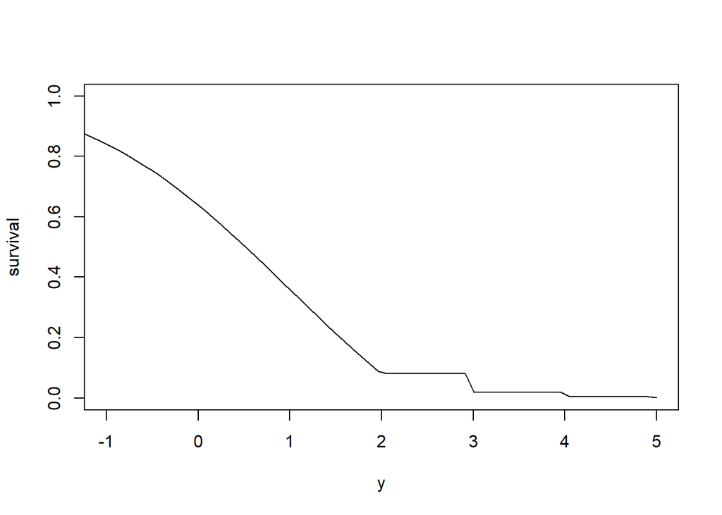

```r
plot(dst_graft_l, "survival", xlim = c(-1, 5))
```

- `mix` function creates a mixture distribution according to the weights of the sub-distributions. The output is classified as “mix” object. The component distributions and the type of random variable are stored in the object as well. Such mixture distribution has been automatic normalized according to the weights.

```r
(dst_mix <- mix(dst_slice_r, dst_3, weights = c(1, 3)))
```

```
## Mixture Distribution
##
## Components:
## # A tibble: 2 x 2
##   distributions probs
##   <named list>  <dbl>
## 1 <slc_rght>     0.25
## 2 <pois>         0.75
```

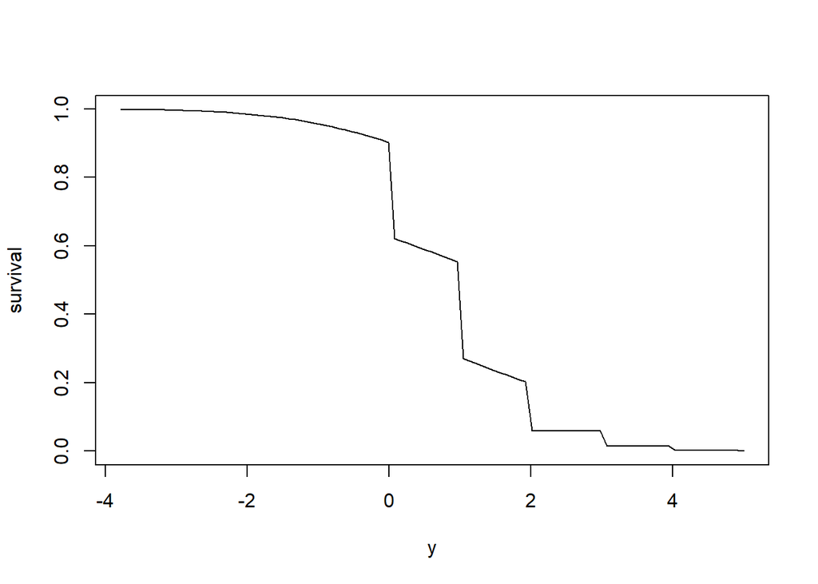

```r
plot(dst_mix, "survival")
```

- There are more advanced operations could be considered in *distplyr*. For example, the popular term **convolution**. However, in the current version of *distplyr*, functions to realize the convolution operations are not included. There are a few considerations for the delaying or absence of the function:
  - The function to realize convolution operations will be too complicated for the package. It needs much more sources to be developed and tested. Currently it is too big of a goal at best.
  - The running of convolution operations needs more performance than other functions in current *distplyr*. As *R* is slow in executing numerical methods, it would be better to code up the convolution functions in *C++*. In *distplyr*, we try to prevent using the numerical methods and such methods only exist for the quantile algorithms, as a part of functions such as inverting a cdf.
  - There exists a package *distr* computing the convolution. The *distr* package is another object oriented manipulation of distributions, however, with too heavy S4 structure compared to *distplyr* with S3 programming. It is also a complicated package for most of the users, and requires a thoroughly reading and learning of its documentation.

### Examples

Here is an application of *distplyr* in the case of flood prediction.

```r
library(distplyr)
library(broom)
library(MASS)
```

The `dms` data records the largest peak associated with snowmelt, atomospheric rivers (AR’s), and the overall maximum flow for each year.

```r
head(dms)
```

| year | ar | max | snow |
| --- | --- | --- | --- |
| 1966 | 0.00 | 48.7 | 48.70000 |
| 1967 | 98.00 | 98.0 | 73.50264 |
| 1968 | 50.49 | 70.2 | 70.20000 |
| 1969 | 9.10 | 63.4 | 63.40000 |
| 1970 | 0.00 | 78.2 | 78.20000 |
| 1971 | 8.91 | 76.2 | 76.20000 |

With the package *distionary*, We can fit normal distributions on the three peaks and get a mix model between snomelt peaks and atomospheric rivers’ peaks. A gev distribution can be obtained based on the snowmelt data as well.

```r
ar_norm <- dst_norm(mean = mean(dms$ar), variance = var(dms$ar))
sn_norm <- dst_norm(mean = mean(dms$snow), variance = var(dms$snow))
max_norm <- dst_norm(mean = mean(dms$max), variance = var(dms$max))
ar_sn_mix <- mix(ar_norm, sn_norm)
sn_gev <- fit_dst_gev(dms$snow)
```

Here is the survival plot of the maximized distribution over AR and SN peaks with the single component dists.

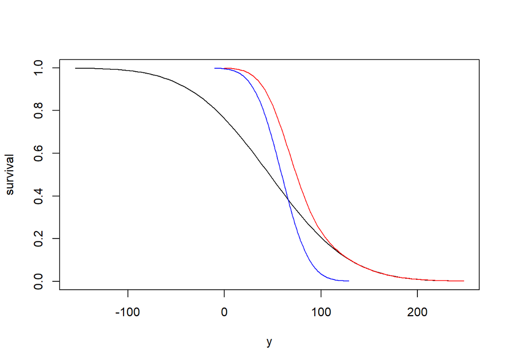

```r
plot(ar_norm, "survival")
plot(sn_norm, "survival", add=TRUE, col="blue")
plot(maximise(ar_norm, sn_norm), "survival", add=TRUE, col="red")
```

We can also get the maximized distribution over two models of SN peaks, which are normal model and gev model. A mixture distribution can be obtained as well.

```r
sn_norm_gev_max <- maximise(sn_norm, sn_gev)
sn_norm_max <- maximise(sn_norm)
sn_norm_gev_mix <- mix(sn_norm, sn_gev)
```

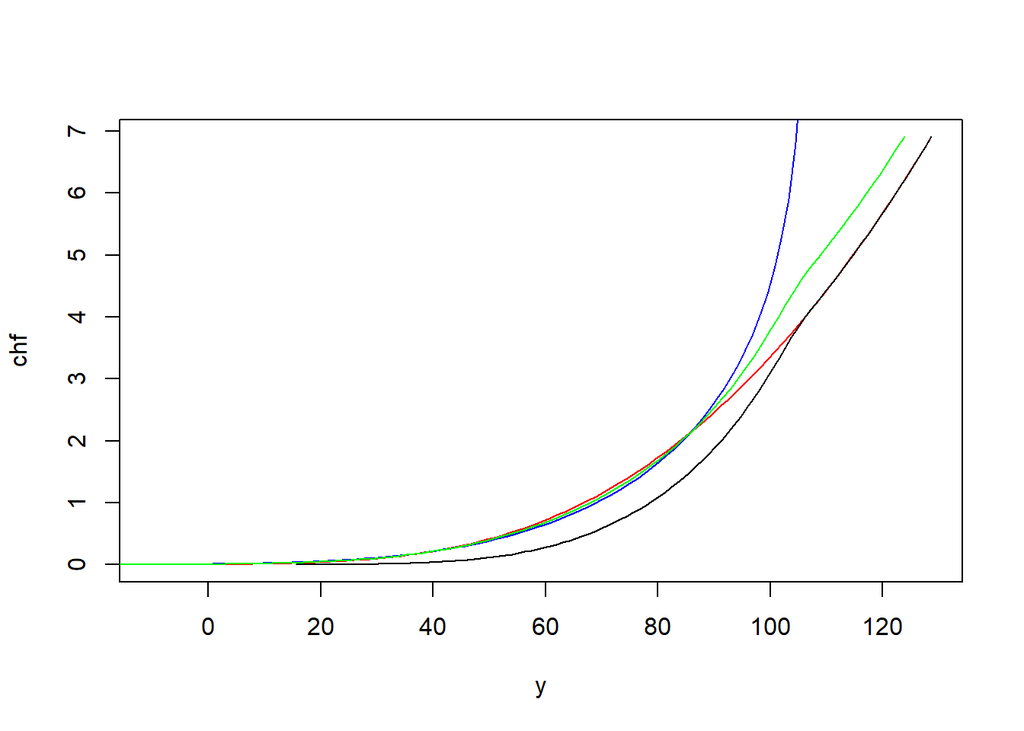

```r
plot(sn_norm, "chf", col="red")
plot(sn_gev, "chf", col="blue", add=TRUE)
plot(sn_norm_gev_max, "chf", col="black", add=TRUE)
plot(sn_norm_gev_mix, "chf", col="green", add=TRUE)
```

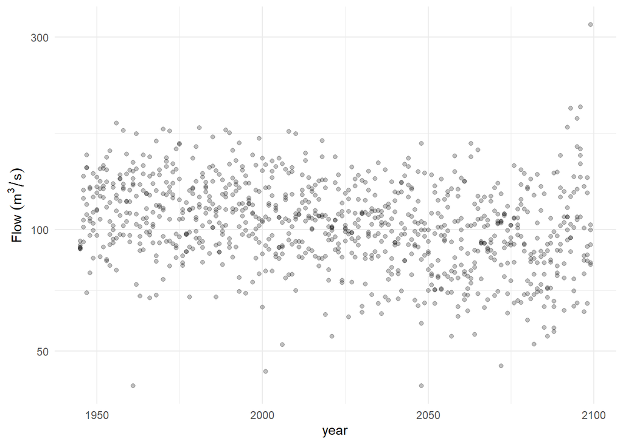

```r
ggplot(ams, aes(year)) +
  geom_point(aes(y = flow), alpha = 0.25) +
  theme_minimal() +
  scale_y_log10(label_flow)
```

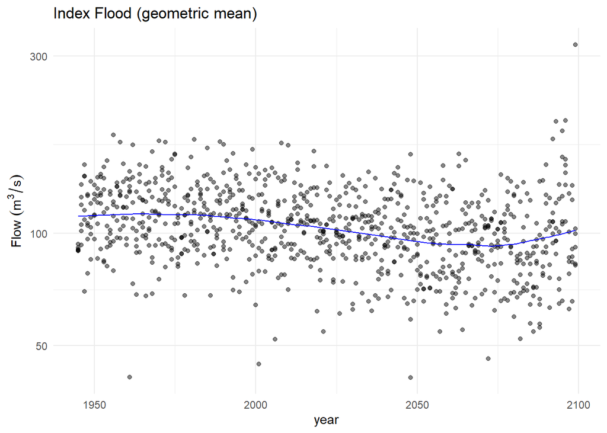

```r
## Index flood
index_model <- loess(
  log(flow) ~ year, data = ams, degree = 1, span = 0.3
)
index_floods <- broom::augment(index_model) %>%
  transmute(year, index_flood = exp(.fitted))

ams_with_index <- ams %>%
  left_join(index_floods, by = "year") %>%
  mutate(ratio = flow / index_flood)

ggplot(ams_with_index, aes(year)) +
  geom_point(aes(y = flow), alpha = 0.1) +
  geom_line(aes(y = index_flood), colour = "blue") +
  scale_y_log10(label_flow) +
  ggtitle("Index Flood (geometric mean)") +
  theme_minimal()
```

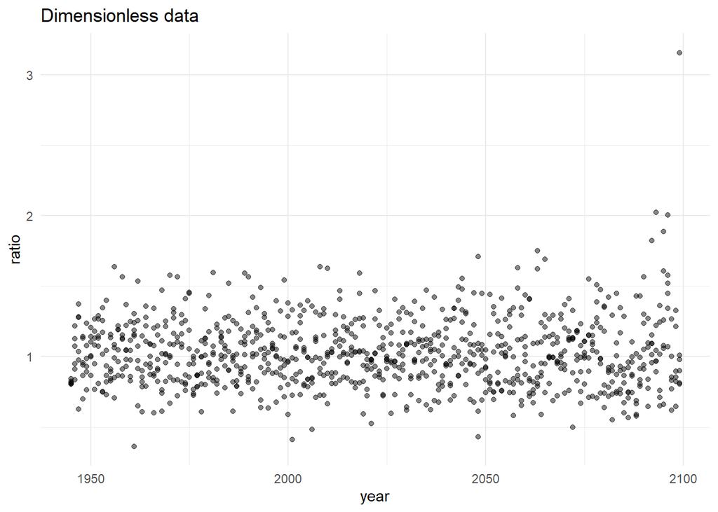

```r
ggplot(ams_with_index, aes(year, ratio)) +
  geom_point(alpha = 0.1) +
  ggtitle("Dimensionless data") +
  theme_minimal()
```

```r
## Ratio GEV distribution
ratio_gev <- fit_dst_gev(ams_with_index$ratio)
```

Make a new column of distributions for each year by multiplying the `ratio_gev` by the `index_flood` estimate.

```r
ams_models <- index_floods %>%
  mutate(dist = map(index_flood, `*`, ratio_gev))
```

```r
head(ams_models)
```

| year | index_flood | dist |
| --- | --- | --- |
| 1945 | 111.2063 |  |
| 1946 | 111.3182 |  |
| 1947 | 111.4368 |  |
| 1948 | 111.5469 |  |
| 1949 | 111.6333 |  |
| 1950 | 111.7137 |  |

Here is an “enframe” workflow within the `ams_models` tibble for evaluating $95\%$ and $5\%$ quantiles

```r
ams_quantiles <- ams_models %>%
  mutate(quantiles = map(dist, enframe_quantile, at = c(0.05, 0.95)))
```

Now we get the distributions for every year and the quantiles of these individual distributions.

```r
head(ams_quantiles)
```

| year | index_flood | dist | quantiles |
| --- | --- | --- | --- |
| 1945 | 111.2063 |  |  |
| 1946 | 111.3182 |  |  |
| 1947 | 111.4368 |  |  |
| 1948 | 111.5469 |  |  |
| 1949 | 111.6333 |  |  |
| 1950 | 111.7137 |  |  |

```r
ams_quantiles$quantiles[1]
```

```
## [[1]]
## # A tibble: 2 x 2
##    .arg quantile
##   <dbl>    <dbl>
## 1  0.05     75.7
## 2  0.95    166.
```

```r
ams_quantiles %>% unnest(quantiles)
```

| year | index_flood | dist | .arg | quantile |
| --- | --- | --- | --- | --- |
| 1945 | 111.20629 |  | 0.05 | 75.74223 |
| 1945 | 111.20629 |  | 0.95 | 166.13597 |
| 1946 | 111.31821 |  | 0.05 | 75.81846 |
| 1946 | 111.31821 |  | 0.95 | 166.30317 |
| 1947 | 111.43679 |  | 0.05 | 75.89922 |
| 1947 | 111.43679 |  | 0.95 | 166.48032 |
| 1948 | 111.54689 |  | 0.05 | 75.97421 |
| 1948 | 111.54689 |  | 0.95 | 166.64481 |
| 1949 | 111.63333 |  | 0.05 | 76.03309 |
| 1949 | 111.63333 |  | 0.95 | 166.77394 |

[output cut: 1850 more lines]

# Conclusion

As shown in the examples, *distplyr* provides a compact and clean syntax for manipulating distributions. The base package *distionary* ensures the reliability of distribution objects used in *distplyr*. Such advantages would be more notable when the composed distributions become more complicated. The users will be able to reduce a large amount of time on developing the complex models and the code style makes the debug process accessible to non-programmers.

In the bundle of *distplyr* and *distionary*, we provide the **verb** and the **noun** to compose the language syntax. Now we show the potential expansibility and the promising application of the package bundle, and promote them as a practical domain-specific language to all analysts.

Ingibergsson, Johann Thor Mogensen, Stefan Hanenberg, Joshua Sunshine, and Ulrik Pagh Schultz. 2018. “Experience Report: Studying the Readability of a Domain Specific Language.” *Proceedings of the 33rd Annual ACM Symposium on Applied Computing*.